# Diamond prices

2022-02-26

## Overview

Diamonds prices depend on their weight, measured in carats. But carats are not the only factor in pricing. Prices also depend on:

- Cut: quality of the diamond from best to worst (Ideal, Premium, Very Good, Good, Fair)
- Color: best(D) to worst(J)
- Clarity: measures how clear the diamond is from best to worst (IF, VVS2, VVS1, VS2, VS1, SI2, SI1, I1)

This application predicts diamond prices based on input values.

## Summary

The “diamonds” dataset is found in the ggplot2 R package. It contains almost 54,000 observations (diamonds).

Let’s take a look at following table. It shows the amounts of diamonds per cut and color

```
##
##                D    E    F    G    H    I    J
##   Fair       163  224  312  314  303  175  119
##   Good       662  933  909  871  702  522  307
##   Very Good 1513 2400 2164 2299 1824 1204  678
##   Premium   1603 2337 2331 2924 2360 1428  808
##   Ideal     2834 3903 3826 4884 3115 2093  896
```

## Plot

The application will allow you to tweak the following plot:

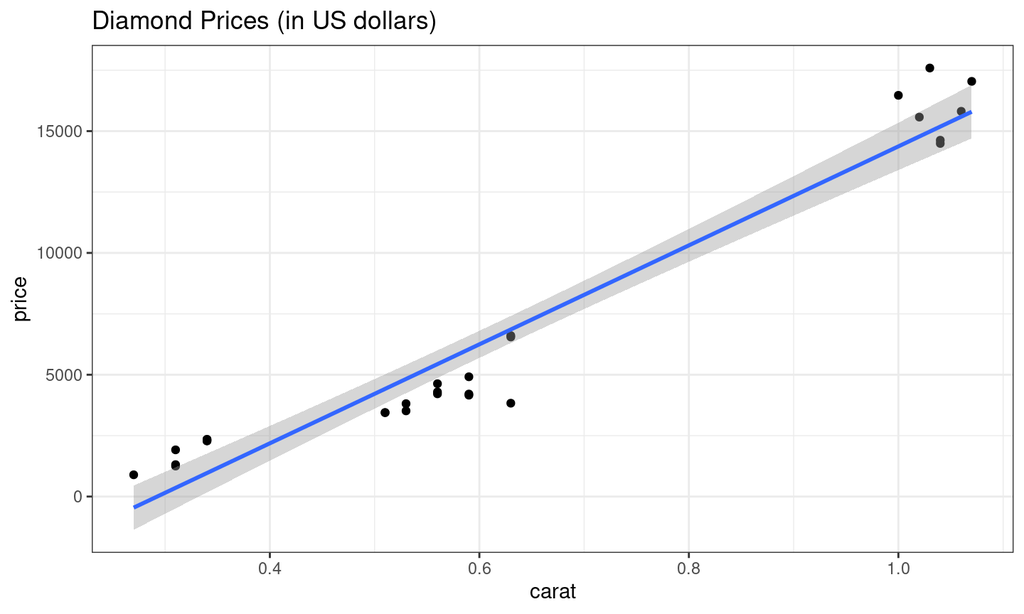

## Final words

Use the controls on the left to tweak the plot. Move the carat slider to get a prediction for the diamond price. The app will automatically react to your inputs.

Enjoy!!!